# Goldenspike, an example of an end-to-end analysis using RAIL

author: Sam Schmidt, Eric Charles, Alex Malz, John Franklin Crenshaw, others...  
last run successfully: April 28, 2023 (with qp-prob >= 0.8.2)

This notebook demonstrates how to use a the various RAIL Modules to draw synthetic samples of fluxes by color, apply physical effects to them, train photo-Z estimators on the samples, test and validate the preformance of those estimators, and to use the RAIL summarization modules to obtain n(z) estimates based on the p(z) estimates.

### Creation

Note that in the parlance of the Creation Module, "degradation" is any post-processing that occurs to the "true" sample generated by the create Engine. This can include adding photometric errors, applying quality cuts, introducing systematic biases, etc.

In this notebook, we will draw both test and training samples from a RAIL Engine object. Then we will demonstrate how to use RAIL degraders to apply effects to those samples.

### Training and Estimation

The RAIL Informer modules "train" or "inform" models used to estimate p(z) given band fluxes (and potentially other information).

The RAIL Estimation modules then use those same models to actually apply the model and extract the p(z) estimates.

### p(z) Validation

The RAIL Validator module applies various metrics

### p(z) to n(z) Summarization

The RAIL Summarization modules convert per-galaxy p(z) posteriors to ensemble n(z) estimates.

### Imports

```python
# Prerquisites: os, numpy, pathlib, pzflow, tables_io
import os
import numpy as np
from pathlib import Path
from pzflow.examples import get_galaxy_data
import tables_io
```

```python
# Various rail modules
import rail
from rail.creation.degradation import LSSTErrorModel, InvRedshiftIncompleteness, LineConfusion, QuantityCut
from rail.creation.engines.flowEngine import FlowModeler, FlowCreator, FlowPosterior
from rail.core.data import TableHandle
from rail.core.stage import RailStage
from rail.core.utilStages import ColumnMapper, TableConverter

from rail.estimation.algos.bpz_lite import Inform_BPZ_lite, BPZ_lite
from rail.estimation.algos.knnpz import Inform_KNearNeighPDF, KNearNeighPDF
from rail.estimation.algos.flexzboost import Inform_FZBoost, FZBoost

from rail.estimation.algos.naiveStack import NaiveStack
from rail.estimation.algos.pointEstimateHist import PointEstimateHist

from rail.evaluation.evaluator import Evaluator
```

RAIL now uses ceci as a back-end, which takes care of a lot of file I/O decisions to be consistent with other choices in DESC.

This bit effectively overrides a ceci default to prevent overwriting previous results, generally good but not necessary for this demo.

The `DataStore` uses `DataHandle` objects to keep track of the connections between the various stages. When one stage returns a `DataHandle` and then you pass that `DataHandle` to another stage, the underlying code can establish the connections needed to build a reproducilble pipeline.

```python
DS = RailStage.data_store
DS.__class__.allow_overwrite = True
```

Here we need a few configuration parameters to deal with differences in data schema between existing PZ codes.

```python
from rail.core.utils import RAILDIR
flow_file = os.path.join(RAILDIR, 'examples/goldenspike/data/pretrained_flow.pkl')
bands = ['u','g','r','i','z','y']
band_dict = {band:f'mag_{band}_lsst' for band in bands}
rename_dict = {f'mag_{band}_lsst_err':f'mag_err_{band}_lsst' for band in bands}
```

## Train the Flow Engine

First we need to train the normalizing flow that will serve as the engine for the notebook.

In the cell below, we load the example galaxy catalog from PZFlow and save it so that it can be used to train the flow. We also set the path where we will save the flow

```python
DATA_DIR = Path().resolve() / "data"
DATA_DIR.mkdir(exist_ok=True)

catalog_file = DATA_DIR / "base_catalog.pq"
catalog = get_galaxy_data().rename(band_dict, axis=1)
tables_io.write(catalog, str(catalog_file.with_suffix("")), catalog_file.suffix[1:])

catalog_file = str(catalog_file)
flow_file = str(DATA_DIR / "trained_flow.pkl")
```

Now we set the parameters for the FlowModeler, i.e. the pipeline stage that trains the flow:

```python
flow_modeler_params = {
    "name": "flow_modeler",
    "input": catalog_file,
    "model": flow_file,
    "seed": 0,
    "phys_cols": {"redshift": [0, 3]},
    "phot_cols": {
        "mag_u_lsst": [17, 35],
        "mag_g_lsst": [16, 32],
        "mag_r_lsst": [15, 30],
        "mag_i_lsst": [15, 30],
        "mag_z_lsst": [14, 29],
        "mag_y_lsst": [14, 28],
    },
    "calc_colors": {"ref_column_name": "mag_i_lsst"},
}
```

Now we will create the flow and train it

```python
flow_modeler = FlowModeler.make_stage(**flow_modeler_params)
```

```
No GPU/TPU found, falling back to CPU. (Set TF_CPP_MIN_LOG_LEVEL=0 and rerun for more info.)
```

```python
flow_modeler.fit_model()
```

```
Inserting handle into data store.  input: /home/runner/work/RAIL/RAIL/examples/goldenspike_examples/data/base_catalog.pq, flow_modeler
Training 30 epochs
Loss:
(0) 21.3266
(1) 4.1139
(2) 3.5145
(3) 1.8794
(4) -0.1582
(5) 1.3641
(6) inf
Training stopping after epoch 6 because training loss diverged.
Inserting handle into data store.  model_flow_modeler: /home/runner/work/RAIL/RAIL/examples/goldenspike_examples/data/inprogress_trained_flow.pkl, flow_modeler
```

```
<rail.core.data.FlowHandle at 0x7f4560fbee20>
```

## Make mock data

Now we will use the trained flow to create training and test data for the photo-z estimators.

For both the training and test data we will:

1. Use the Flow to produce some synthetic data
2. Use the LSSTErrorModel to add photometric errors
3. Use the FlowPosterior to estimate the redshift posteriors for the degraded sample
4. Use the ColumnMapper to rename the error columns so that they match the names in DC2.
5. Use the TableConverter to convert the data to a numpy dictionary, which will be stored in a hdf5 file with the same schema as the DC2 data

### Training sample

For the training data we are going to apply a couple of extra degradation effects to the data beyond what we do to create test data, as the training data will have some spectroscopic incompleteness. This will allow us to see how the trained models perform with imperfect training data.

More details about the degraders are available in the `rail/examples/creation_examples/degradation_demo.ipynb` notebook.

```python
flow_creator_train = FlowCreator.make_stage(
    name='flow_creator_train',
    model=flow_modeler.get_handle("model"),
    n_samples=50,
    seed=1235,
)

lsst_error_model_train = LSSTErrorModel.make_stage(
    name='lsst_error_model_train',
    bandNames=band_dict,
    seed=29,
)

inv_redshift = InvRedshiftIncompleteness.make_stage(
    name='inv_redshift',
    pivot_redshift=1.0,
)

line_confusion = LineConfusion.make_stage(
    name='line_confusion',
    true_wavelen=5007.,
    wrong_wavelen=3727.,
    frac_wrong=0.05,
)

quantity_cut = QuantityCut.make_stage(
    name='quantity_cut',
    cuts={'mag_i_lsst': 25.0},
)

col_remapper_train = ColumnMapper.make_stage(
    name='col_remapper_train',
    columns=rename_dict,
)

table_conv_train = TableConverter.make_stage(
    name='table_conv_train',
    output_format='numpyDict',
)
```

```python
train_data_orig = flow_creator_train.sample(150, 1235)
train_data_errs = lsst_error_model_train(train_data_orig,seed=66)
train_data_inc = inv_redshift(train_data_errs)
train_data_conf = line_confusion(train_data_inc)
train_data_cut = quantity_cut(train_data_conf)
train_data_pq = col_remapper_train(train_data_cut)
train_data = table_conv_train(train_data_pq)
```

```
Inserting handle into data store.  output_flow_creator_train: inprogress_output_flow_creator_train.pq, flow_creator_train
Inserting handle into data store.  output_lsst_error_model_train: inprogress_output_lsst_error_model_train.pq, lsst_error_model_train
Inserting handle into data store.  output_inv_redshift: inprogress_output_inv_redshift.pq, inv_redshift
Inserting handle into data store.  output_line_confusion: inprogress_output_line_confusion.pq, line_confusion
Inserting handle into data store.  output_quantity_cut: inprogress_output_quantity_cut.pq, quantity_cut
Inserting handle into data store.  output_col_remapper_train: inprogress_output_col_remapper_train.pq, col_remapper_train
Inserting handle into data store.  output_table_conv_train: inprogress_output_table_conv_train.hdf5, table_conv_train
```

Let's examine the quantities that we've generated, we'll use the handy `tables_io` package to temporarily write to a pandas dataframe for quick writeout of the columns:

```python
train_table = tables_io.convertObj(train_data.data, tables_io.types.PD_DATAFRAME)
train_table.head()
```

|  | redshift | mag_u_lsst | mag_err_u_lsst | mag_g_lsst | mag_err_g_lsst | mag_r_lsst | mag_err_r_lsst | mag_i_lsst | mag_err_i_lsst | mag_z_lsst | mag_err_z_lsst | mag_y_lsst | mag_err_y_lsst |
| --- | --- | --- | --- | --- | --- | --- | --- | --- | --- | --- | --- | --- | --- |
| 0 | 0.776368 | 27.096006 | 0.461011 | 26.555770 | 0.104944 | 25.347148 | 0.035449 | 24.179230 | 0.018918 | 23.598360 | 0.019891 | 23.441322 | 0.038977 |
| 1 | 0.707868 | 26.408446 | 0.269012 | 26.318758 | 0.085249 | 25.584306 | 0.043736 | 24.988744 | 0.038232 | 24.598414 | 0.047699 | 24.638287 | 0.112221 |
| 2 | 1.089314 | 25.139119 | 0.091495 | 24.467253 | 0.016957 | 23.384858 | 0.007806 | 22.341993 | 0.006124 | 8.789131 | 0.005000 | 6.992166 | 0.005000 |
| 3 | 0.484889 | 25.979984 | 0.188629 | 25.557817 | 0.043487 | 25.104019 | 0.028621 | 24.368909 | 0.022229 | 24.368547 | 0.038904 | 24.071658 | 0.068173 |
| 4 | 0.553523 | 25.291620 | 0.104513 | 24.187720 | 0.013566 | 23.348308 | 0.007660 | 22.705591 | 0.006977 | 22.343707 | 0.007994 | 22.300595 | 0.014683 |

You see that we've generated redshifts, ugrizy magnitudes, and magnitude errors with names that match those in the cosmoDC2_v1.1.4_image data.

### Testing sample

For the test sample we will:

1. Use the Flow to produce some synthetic data
2. Use the LSSTErrorModel to smear the data
3. Use the FlowPosterior to estimate the redshift posteriors for the degraded sample
4. Use ColumnMapper to rename some of the columns to match DC2
5. Use the TableConverter to convert the data to a numpy dictionary, which will be stored in a hdf5 file with the same schema as the DC2 data

```python
flow_creator_test = FlowCreator.make_stage(
    name='flow_creator_test',
    model=flow_modeler.get_handle("model"),
    n_samples=50,
)

lsst_error_model_test = LSSTErrorModel.make_stage(
    name='lsst_error_model_test',
    bandNames=band_dict,
)

flow_post_test = FlowPosterior.make_stage(
    name='flow_post_test',
    model=flow_modeler.get_handle("model"),
    column='redshift',
    grid=np.linspace(0., 5., 21),
)

col_remapper_test = ColumnMapper.make_stage(
    name='col_remapper_test',
    columns=rename_dict,
    hdf5_groupname='',
)

table_conv_test = TableConverter.make_stage(
    name='table_conv_test',
    output_format='numpyDict',
)
```

```python
test_data_orig = flow_creator_test.sample(150, 1234)
test_data_errs = lsst_error_model_test(test_data_orig,seed=58)
test_data_post = flow_post_test.get_posterior(test_data_errs, err_samples=None)
test_data_pq = col_remapper_test(test_data_errs)
test_data = table_conv_test(test_data_pq)
```

```
Inserting handle into data store.  output_flow_creator_test: inprogress_output_flow_creator_test.pq, flow_creator_test
Inserting handle into data store.  output_lsst_error_model_test: inprogress_output_lsst_error_model_test.pq, lsst_error_model_test
Inserting handle into data store.  output_flow_post_test: inprogress_output_flow_post_test.hdf5, flow_post_test
Inserting handle into data store.  output_col_remapper_test: inprogress_output_col_remapper_test.pq, col_remapper_test
Inserting handle into data store.  output_table_conv_test: inprogress_output_table_conv_test.hdf5, table_conv_test
```

```python
test_table = tables_io.convertObj(test_data.data, tables_io.types.PD_DATAFRAME)
test_table.head()
```

|  | redshift | mag_u_lsst | mag_err_u_lsst | mag_g_lsst | mag_err_g_lsst | mag_r_lsst | mag_err_r_lsst | mag_i_lsst | mag_err_i_lsst | mag_z_lsst | mag_err_z_lsst | mag_y_lsst | mag_err_y_lsst |
| --- | --- | --- | --- | --- | --- | --- | --- | --- | --- | --- | --- | --- | --- |
| 0 | 0.182804 | 26.135859 | 0.214929 | 24.984569 | 0.026282 | 24.388399 | 0.015583 | 24.028153 | 0.016684 | 23.890909 | 0.025570 | 23.627875 | 0.045987 |
| 1 | 0.539859 | 25.395984 | 0.114433 | 24.680702 | 0.020256 | 23.799778 | 0.010022 | 23.402364 | 0.010344 | 23.223785 | 0.014611 | 22.934286 | 0.024972 |
| 2 | 1.629625 | NaN | NaN | 27.407328 | 0.217518 | 26.308056 | 0.083064 | 25.527529 | 0.061668 | 24.960131 | 0.065749 | 24.500825 | 0.099516 |
| 3 | 0.402639 | 27.874355 | 0.796538 | 27.438832 | 0.223296 | 26.351841 | 0.086331 | 25.955206 | 0.089993 | 25.555003 | 0.110991 | 25.959948 | 0.339467 |
| 4 | 2.036373 | 25.912178 | 0.178140 | 25.729358 | 0.050623 | 25.368662 | 0.036130 | 24.942092 | 0.036686 | 24.377120 | 0.039200 | 23.898813 | 0.058489 |

## "Inform" some estimators

More details about the process of "informing" or "training" the models used by the estimators is available in the `rail/examples/estimation_examples/RAIL_estimation_demo.ipynb` notebook.

We use "inform" rather than "train" to generically refer to the preprocessing of any prior information. For a machine learning estimator, that prior information is a training set, but it can also be an SED template library for a template-fitting or hybrid estimator.

```python
inform_bpz = Inform_BPZ_lite.make_stage(
    name="inform_bpz",
    model="bpz.pkl",
    hdf5_groupname="",
)

inform_knn = Inform_KNearNeighPDF.make_stage(
    name='inform_knn',
    nondetect_val=np.nan,
    model='knnpz.pkl',
    hdf5_groupname='',
)

inform_fzboost = Inform_FZBoost.make_stage(
    name='inform_FZBoost',
    model='fzboost.pkl',
    hdf5_groupname='',
)
```

```python
inform_bpz.inform(train_data)
inform_knn.inform(train_data)
inform_fzboost.inform(train_data)
```

```
using 61 galaxies in calculation
best values for fo and kt:
[1.]
[0.3]
minimizing for type 0
best fit z0, alpha, km for type 0: [ 5.30299812e-01  1.72669318e+00 -7.57839184e-04]
Inserting handle into data store.  model_inform_bpz: inprogress_bpz.pkl, inform_bpz
split into 46 training and 15 validation samples
finding best fit sigma and NNeigh...



best fit values are sigma=0.075 and numneigh=5



Inserting handle into data store.  model_inform_knn: inprogress_knnpz.pkl, inform_knn
stacking some data...
read in training data
fit the model...
finding best bump thresh...
finding best sharpen parameter...
Inserting handle into data store.  model_inform_FZBoost: inprogress_fzboost.pkl, inform_FZBoost
```

```
<rail.core.data.ModelHandle at 0x7f44d1ac45e0>
```

**If you run into issues here:**

If you've installed rail and bpz to different directories (most commonly, you've installed rail from source and bpz from PyPI), you may run into an issue where rail cannot locate a file installed by bpz.

To fix this, find your test_bpz.columns file in your bpz directory ([or grab a new one here on GitHub](https://github.com/LSSTDESC/rail_bpz/blob/main/src/rail/examples/estimation/configs/test_bpz.columns%3E)) and copy it into your rail directory to `/RAIL/src/rail/examples/estimation_examples/configs/test_bpz.columns`.

Alternatively, if you don't want to move files, you should be able rewrite code to replace the configured paths with your actual `test_bpz.columns` path (inform stage: [bpz_lite.py L89](https://github.com/LSSTDESC/rail_bpz/blob/65870ffd93ba35356a1af44104a0a78530085789/src/rail/estimation/algos/bpz_lite.py#L89) and estimation: [bpz_lite.py L259](https://github.com/LSSTDESC/rail_bpz/blob/65870ffd93ba35356a1af44104a0a78530085789/src/rail/estimation/algos/bpz_lite.py#L259%3E)).

## Estimate photo-z posteriors

More details about the estimators is available in the `rail/examples/estimation_examples/RAIL_estimation_demo.ipynb` notebook.

```python
estimate_bpz = BPZ_lite.make_stage(
    name='estimate_bpz',
    hdf5_groupname='',
    model=inform_bpz.get_handle('model'),
)

estimate_knn = KNearNeighPDF.make_stage(
    name='estimate_knn',
    hdf5_groupname='',
    nondetect_val=np.nan,
    model=inform_knn.get_handle('model'),
)

estimate_fzboost = FZBoost.make_stage(
    name='test_FZBoost',
    nondetect_val=np.nan,
    model=inform_fzboost.get_handle('model'),
    hdf5_groupname='',
    aliases=dict(input='test_data', output='fzboost_estim'),
)
```

```python
knn_estimated = estimate_knn.estimate(test_data)
fzboost_estimated = estimate_fzboost.estimate(test_data)
bpz_estimated = estimate_bpz.estimate(test_data)
```

[output not shown]

[output cut: 193 more lines]

[output not shown]

## Evaluate the estimates

Now we evaluate metrics on the estimates, separately for each estimator.

Each call to the `Evaluator.evaluate` will create a table with the various performance metrics. We will store all of these tables in a dictionary, keyed by the name of the estimator.

```python
eval_dict = dict(bpz=bpz_estimated, fzboost=fzboost_estimated, knn=knn_estimated)
truth = test_data_orig

result_dict = {}
for key, val in eval_dict.items():
    the_eval = Evaluator.make_stage(name=f'{key}_eval', truth=truth)
    result_dict[key] = the_eval.evaluate(val, truth)
```

[output not shown]

```
WARNING:root:Removed 5 PITs from the sample.
```

[output not shown]

The Pandas DataFrame output format conveniently makes human-readable printouts of the metrics.  
This next cell will convert everything to Pandas.

```python
results_tables = {key:tables_io.convertObj(val.data, tables_io.types.PD_DATAFRAME) for key,val in result_dict.items()}
```

```python
results_tables['knn']
```

|  | PIT_AD_stat | PIT_AD_pval | PIT_AD_significance_level | PIT_CvM_stat | PIT_CvM_pval | PIT_CvM_significance_level | PIT_KS_stat | PIT_KS_pval | PIT_KS_significance_level | PIT_OutRate_stat | PIT_OutRate_pval | PIT_OutRate_significance_level | POINT_SimgaIQR | POINT_Bias | POINT_OutlierRate | POINT_SigmaMAD | CDE_stat | CDE_pval |
| --- | --- | --- | --- | --- | --- | --- | --- | --- | --- | --- | --- | --- | --- | --- | --- | --- | --- | --- |
| 0 | 19.288725 | None | 0.001 | 5.954441 | None | None | 0.363699 | None | None | None | None | None | 0.32706 | -0.10984 | 0.0 | 0.284233 | -0.349735 | NaN |

```python
results_tables['fzboost']
```

|  | PIT_AD_stat | PIT_AD_pval | PIT_AD_significance_level | PIT_CvM_stat | PIT_CvM_pval | PIT_CvM_significance_level | PIT_KS_stat | PIT_KS_pval | PIT_KS_significance_level | PIT_OutRate_stat | PIT_OutRate_pval | PIT_OutRate_significance_level | POINT_SimgaIQR | POINT_Bias | POINT_OutlierRate | POINT_SigmaMAD | CDE_stat | CDE_pval |
| --- | --- | --- | --- | --- | --- | --- | --- | --- | --- | --- | --- | --- | --- | --- | --- | --- | --- | --- |
| 0 | 26.132955 | None | 0.001 | 5.418557 | None | None | 0.364123 | None | None | None | None | None | 0.229569 | -0.055339 | 0.006667 | 0.235463 | 0.55666 | NaN |

```python
results_tables['bpz']
```

|  | PIT_AD_stat | PIT_AD_pval | PIT_AD_significance_level | PIT_CvM_stat | PIT_CvM_pval | PIT_CvM_significance_level | PIT_KS_stat | PIT_KS_pval | PIT_KS_significance_level | PIT_OutRate_stat | PIT_OutRate_pval | PIT_OutRate_significance_level | POINT_SimgaIQR | POINT_Bias | POINT_OutlierRate | POINT_SigmaMAD | CDE_stat | CDE_pval |
| --- | --- | --- | --- | --- | --- | --- | --- | --- | --- | --- | --- | --- | --- | --- | --- | --- | --- | --- |
| 0 | 14.375369 | None | 0.001 | 2.970253 | None | None | 0.219203 | None | None | None | None | None | 0.147649 | -0.047307 | 0.146667 | 0.149275 | 12.004692 | NaN |

## Summarize the per-galaxy redshift constraints to make population-level distributions

First we make the stages, then execute them, then plot the output.

```python
point_estimate_test = PointEstimateHist.make_stage(name='point_estimate_test')
naive_stack_test = NaiveStack.make_stage(name='naive_stack_test')
```

```python
point_estimate_ens = point_estimate_test.summarize(eval_dict['bpz'])
naive_stack_ens = naive_stack_test.summarize(eval_dict['bpz'])
```

```
Inserting handle into data store.  output_point_estimate_test: inprogress_output_point_estimate_test.hdf5, point_estimate_test
Inserting handle into data store.  single_NZ_point_estimate_test: inprogress_single_NZ_point_estimate_test.hdf5, point_estimate_test
Inserting handle into data store.  output_naive_stack_test: inprogress_output_naive_stack_test.hdf5, naive_stack_test
Inserting handle into data store.  single_NZ_naive_stack_test: inprogress_single_NZ_naive_stack_test.hdf5, naive_stack_test
```

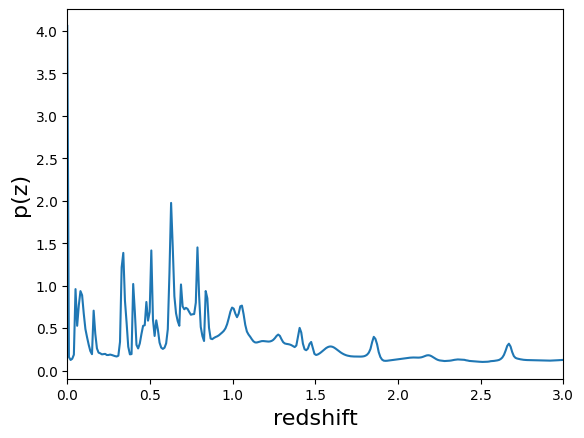

```python
_ = naive_stack_ens.data.plot_native(xlim=(0,3))
```

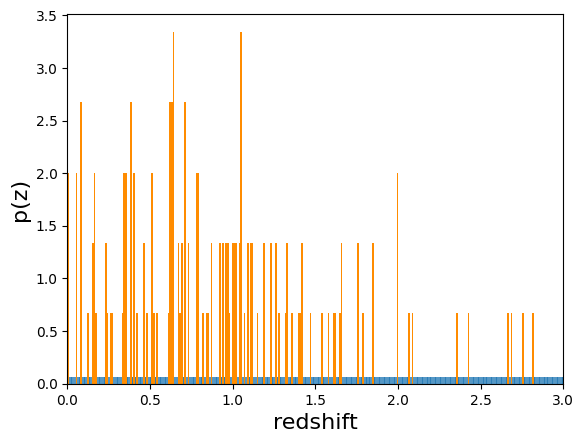

```python
_ = point_estimate_ens.data.plot_native(xlim=(0,3))
```

### Convert this to a `ceci` Pipeline

Now that we have all these stages defined and configured, and that we have established the connections between them by passing `DataHandle` objects between them, we can build a `ceci` Pipeline.

```python
import ceci
pipe = ceci.Pipeline.interactive()
stages = [
    # train the flow
    flow_modeler,
    # create the training catalog
    flow_creator_train, lsst_error_model_train, inv_redshift,
    line_confusion, quantity_cut, col_remapper_train, table_conv_train,
    # create the test catalog
    flow_creator_test, lsst_error_model_test, col_remapper_test, table_conv_test,
    # inform the estimators
    inform_bpz, inform_knn, inform_fzboost,
    # estimate posteriors
    estimate_bpz, estimate_knn, estimate_fzboost,
    # estimate n(z), aka "summarize"
    point_estimate_test, naive_stack_test,
]
for stage in stages:
    pipe.add_stage(stage)
```

```python
pipe.initialize(dict(input=catalog_file), dict(output_dir='.', log_dir='.', resume=False), None)
```

```
(({'flow_modeler': <Job flow_modeler>,
   'flow_creator_test': <Job flow_creator_test>,
   'lsst_error_model_test': <Job lsst_error_model_test>,
   'col_remapper_test': <Job col_remapper_test>,
   'table_conv_test': <Job table_conv_test>,
   'flow_creator_train': <Job flow_creator_train>,
   'lsst_error_model_train': <Job lsst_error_model_train>,
   'inv_redshift': <Job inv_redshift>,
   'line_confusion': <Job line_confusion>,
   'quantity_cut': <Job quantity_cut>,
   'col_remapper_train': <Job col_remapper_train>,
   'table_conv_train': <Job table_conv_train>,
   'inform_FZBoost': <Job inform_FZBoost>,
   'test_FZBoost': <Job test_FZBoost>,
   'inform_knn': <Job inform_knn>,
   'estimate_knn': <Job estimate_knn>,
   'inform_bpz': <Job inform_bpz>,
   'estimate_bpz': <Job estimate_bpz>,
   'naive_stack_test': <Job naive_stack_test>,
   'point_estimate_test': <Job point_estimate_test>},
  [<rail.creation.engines.flowEngine.FlowModeler at 0x7f45b473a9a0>,
   <rail.creation.engines.flowEngine.FlowCreator at 0x7f455e195df0>,
   LSSTErrorModel parameters:

   Model for bands: mag_u_lsst, mag_g_lsst, mag_r_lsst, mag_i_lsst, mag_z_lsst, mag_y_lsst

   Using error type point
   Exposure time = 30.0 s
   Number of years of observations = 10.0
   Mean visits per year per band:
      mag_u_lsst: 5.6, mag_g_lsst: 8.0, mag_r_lsst: 18.4, mag_i_lsst: 18.4, mag_z_lsst: 16.0, mag_y_lsst: 16.0
   Airmass = 1.2
   Irreducible system error = 0.005
   Magnitudes dimmer than 30.0 are set to nan
   gamma for each band:
      mag_u_lsst: 0.038, mag_g_lsst: 0.039, mag_r_lsst: 0.039, mag_i_lsst: 0.039, mag_z_lsst: 0.039, mag_y_lsst: 0.039

   The coadded 5-sigma limiting magnitudes are:
   mag_u_lsst: 26.04, mag_g_lsst: 27.29, mag_r_lsst: 27.31, mag_i_lsst: 26.87, mag_z_lsst: 26.23, mag_y_lsst: 25.30

```

[output cut: 46 more lines]

```
   Degrader that applies the following cuts to a pandas DataFrame:
   {column: (min, max), ...}
   {'mag_i_lsst': (-inf, 25.0)},
   Stage that applies remaps the following column names in a pandas DataFrame:
   f{str(self.config.columns)},
   <rail.core.utilStages.TableConverter at 0x7f455a76e2b0>,
   <rail.estimation.algos.flexzboost.Inform_FZBoost at 0x7f455d5dd880>,
   <rail.estimation.algos.flexzboost.FZBoost at 0x7f44e5a70850>,
   <rail.estimation.algos.knnpz.Inform_KNearNeighPDF at 0x7f455d5e9430>,
   <rail.estimation.algos.knnpz.KNearNeighPDF at 0x7f44d1ad9df0>,
   <rail.estimation.algos.bpz_lite.Inform_BPZ_lite at 0x7f455d5e9f10>,
   <rail.estimation.algos.bpz_lite.BPZ_lite at 0x7f44d1ad94f0>,
   <rail.estimation.algos.naiveStack.NaiveStack at 0x7f44d1ad2910>,
   <rail.estimation.algos.pointEstimateHist.PointEstimateHist at 0x7f455e185fd0>]),
 {'output_dir': '.', 'log_dir': '.', 'resume': False})
```

```python
pipe.save('tmp_goldenspike.yml')
```

### Read back the pipeline and run it

```python
pr = ceci.Pipeline.read('tmp_goldenspike.yml')
```

```python
pr.run()
```

```
Executing flow_modeler
Command is:
OMP_NUM_THREADS=1   python3 -m ceci rail.creation.engines.flowEngine.FlowModeler   --input=/home/runner/work/RAIL/RAIL/examples/goldenspike_examples/data/base_catalog.pq   --name=flow_modeler   --config=tmp_goldenspike_config.yml   --model=.//home/runner/work/RAIL/RAIL/examples/goldenspike_examples/…
Output writing to ./flow_modeler.out

Job flow_modeler has completed successfully!

Executing flow_creator_test
Command is:
OMP_NUM_THREADS=1   python3 -m ceci rail.creation.engines.flowEngine.FlowCreator   --model=.//home/runner/work/RAIL/RAIL/examples/goldenspike_examples/data/trained_flow.pkl   --name=flow_creator_test   --config=tmp_goldenspike_config.yml   --output=./output_flow_creator_test.pq
Output writing to ./flow_creator_test.out

Job flow_creator_test has completed successfully!

Executing lsst_error_model_test
Command is:
OMP_NUM_THREADS=1   python3 -m ceci rail.creation.degradation.lsst_error_model.LSSTErrorModel   --input=./output_flow_creator_test.pq   --name=lsst_error_model_test   --config=tmp_goldenspike_config.yml   --output=./output_lsst_error_model_test.pq
Output writing to ./lsst_error_model_test.out

Job lsst_error_model_test has completed successfully!

Executing col_remapper_test
Command is:
OMP_NUM_THREADS=1   python3 -m ceci rail.core.utilStages.ColumnMapper   --input=./output_lsst_error_model_test.pq   --name=col_remapper_test   --config=tmp_goldenspike_config.yml   --output=./output_col_remapper_test.pq
Output writing to ./col_remapper_test.out

Job col_remapper_test has completed successfully!

Executing table_conv_test
Command is:
OMP_NUM_THREADS=1   python3 -m ceci rail.core.utilStages.TableConverter   --input=./output_col_remapper_test.pq   --name=table_conv_test   --config=tmp_goldenspike_config.yml   --output=./output_table_conv_test.hdf5
Output writing to ./table_conv_test.out

Job table_conv_test has completed successfully!

Executing flow_creator_train
Command is:
OMP_NUM_THREADS=1   python3 -m ceci rail.creation.engines.flowEngine.FlowCreator   --model=.//home/runner/work/RAIL/RAIL/examples/goldenspike_examples/data/trained_flow.pkl   --name=flow_creator_train   --config=tmp_goldenspike_config.yml   --output=./output_flow_creator_train.pq
Output writing to ./flow_creator_train.out

```

[output cut: 84 more lines]

```
Job estimate_bpz has completed successfully!

Executing naive_stack_test
Command is:
OMP_NUM_THREADS=1   python3 -m ceci rail.estimation.algos.naiveStack.NaiveStack   --input=./output_estimate_bpz.hdf5   --name=naive_stack_test   --config=tmp_goldenspike_config.yml   --output=./output_naive_stack_test.hdf5   --single_NZ=./single_NZ_naive_stack_test.hdf5
Output writing to ./naive_stack_test.out

Job naive_stack_test has completed successfully!

Executing point_estimate_test
Command is:
OMP_NUM_THREADS=1   python3 -m ceci rail.estimation.algos.pointEstimateHist.PointEstimateHist   --input=./output_estimate_bpz.hdf5   --name=point_estimate_test   --config=tmp_goldenspike_config.yml   --output=./output_point_estimate_test.hdf5   --single_NZ=./single_NZ_point_estimate_test.hdf5
Output writing to ./point_estimate_test.out

Job point_estimate_test has completed successfully!
```

```
0
```

# Clean up:

Finally, you'll notice that we've written a large number of temporary files in the course of running this demo, to delete these and clean up the directory just run the `cleanup.sh` script in this directory to delete the data files.